# Module 2a: Random Number Generation

# Random Number Generation

R provides a number of pseudo-random number functions that generate sequences of numbers from various well-known probability distributions. Random number functions use a parameter, referred to as the seed, which specifies a starting point of the random number stream (thus computer generated random number sequences are pseudo-random). When the seed is not specified, the computer generates a starting value, A different seed is generated every time you run a random function. To specify a seed value, you use the built-in function set.seed() prior to running the random number function. For reproducible results, you will need to set the seed before every random function. Note that setting the same seed will produce two identical distributions if the function is the same. In module 1a, we used the sample function to generate 2 vectors - one for gender and one for smokers to demonstrate tables. Note that if the same seed had been used in both instances (as below) - all of our females would have been smokers and all of our males would have been non-smokers.

```r
# data frame with Gender and Smoking Status Randomly assigned
set.seed(123)
Gender <- sample(c('Female', 'Male'), 50, replace = T)
set.seed(123)
Smoker <- sample(c('Smoker', 'NonSmoker'), 50, replace = T)
df5 <- data.frame(Gender, Smoker)
# look at Smoking Status by Gender
table(df5$Gender, df5$Smoker)
```

```
##
##          NonSmoker Smoker
##   Female         0     25
##   Male          25      0
```

If the seed had not been set a second time, the computer would’ve generated a seed and the results would’ve been essentially impossible to reproduce. Note: The same seed will not always produce the identical distribution on different machines and/or operating systems.

Each sequence of random numbers generated by R functions will have the characteristics of the probability distribution from which it was selected.

## The uniform distribuition

The runif() function generates random numbers in a uniform distribution. The runif() function accepts arguments for the number of numbers generated (n) and the minimum (min) and maximum (max) values. n is required, the default min = 0 and max = 1.

```r
set.seed(15)
uniform <- runif(n = 100) # generate 100 numbers in a uniform distribution with
# min = 0 and max = 1
head(uniform)
```

```
## [1] 0.6021140 0.1950439 0.9664587 0.6509055 0.3670719 0.9888592
```

```r
# for more information on the uniform distribution and its associated functions
# in R
?Uniform
```

Recall that a sample of numbers from a Uniform (0,1) distribution has the following theoretical characteristics:  
1. All numbers fall between the values 0 and 1  
2. Mean of the sample is 0.5  
3. The standard deviation is sqrt(1/12) = 0.29

There are many tools available to explore data in R. Here we will look at using the describe function in the psych package to examine our vector.

```r
# only needs to be run once
install.packages('psych')
```

```r
library(psych)
describe(uniform)
```

```
##    vars   n mean   sd median trimmed  mad  min max range  skew kurtosis
## X1    1 100 0.57 0.29   0.66    0.59 0.34 0.01   1  0.99 -0.35    -1.25
##      se
## X1 0.03
```

Now lets look at some plots of our distribution.

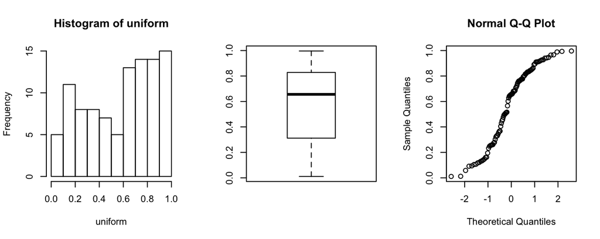

```r
par(mfrow = c(1,3)) # causes all 3 plots to be plotted side by side
hist(uniform) # generate a histogram of our vector
boxplot(uniform) # generate a box plot
qqnorm(uniform) # generate a qqplot
```

Is this what you were expecting? What about if we increase n to 100,000?

```r
set.seed(15)
# generate 100,000 numbers in a uniform distribution with
# min = 0 and max = 1
uniformbig <- runif(n = 100000)
describe(uniformbig)
```

```
##    vars     n mean   sd median trimmed  mad min max range  skew kurtosis
## X1    1 1e+05  0.5 0.29    0.5     0.5 0.37   0   1     1 -0.01     -1.2
##    se
## X1  0
```

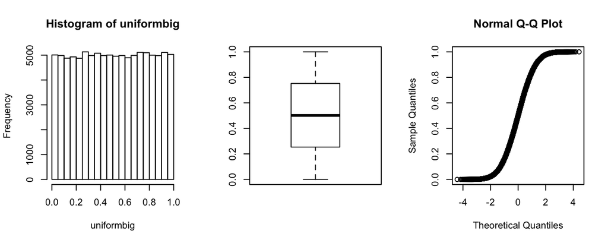

```r
par(mfrow = c(1,3)) # causes all 3 plots to be plotted side by side
hist(uniformbig)
boxplot(uniformbig)
qqnorm(uniformbig)
```

## The binomial distribtuion

The Binomial distribution refers to random variables with 2 possible outcomes. Which of the following have binomial outcomes?  
1. Flipping a coin  
2. Smoking status  
3. Age

Actually, the question is harder than it looks. Obviously, there are only 2 outcomes for flipping a fair coin. It would seem that smoking status has a binomial outcome, but what if we are interested in current, former, and never smokers? This would no longer be binomial. Age, if used continuously will not be binomial, but what if we were interested in whether or not a person is over 21 – then age would be considered binomial. It is critical that you have a clear definition of the processes you are studying, prior to any analyses.

Similar to generating random numbers from a uniform distribution, you can generate a series of random numbers from the binomial distribution. T he function rbinom() is used to generate a n numbers where each number represents the number of successes, ‘x’, in a single binomial experiment of ‘size’ trials and ‘p’ is the probability of a success for a single trial. This function requires we specify three parameters:  
* n = the number of observations, or sample size to generate  
* size = the number of trials for each observation  
* p = the probability of success (bounded by 0 and 1)

```r
set.seed(67)
x <- rbinom(1, 1000, 0.01)
x
```

```
## [1] 14
```

What is x in this instance?  
It is the number of success in 1,000 trials and we would expect it to be close to 1000*0.01 = 10 - is it?

What about if we do 4 experiments of flipping a fair coin 8 times?

```r
set.seed(99)
x <- rbinom(4, 8, 0.5)
x
```

```
## [1] 4 2 5 7
```

```r
# for more information on the binomial distribution and its associated functions
# in R
?Binomial
```

## The Poisson Distribution

The Poisson distribution represents the total number of occurrences of rare events in a predefined period of time, distance, etc. when the probability of an event occurring in a short time frame is close to zero and the probability remains the same for any short interval in the time observed period. It can be applied to events occurring in time or space and it’s characterized by one parameter, $\mu$, which is the mean and the variance of the distribution.  
Recall that the Poisson distribution generates count data, taking on integer values 0, 1, 2, 3, … How is this different from the binomial distribution? The range of the binomial distribution is 0, 1, 2, 3, …n. In other words, there is a maximum value (n) that can be attained, whereas the Poisson distribution can range from 0 to $\infty$ depending of the length of time the experiment is observed. rpois() requires the parameters n and lambda where n = number of random values to return and lambda = the average number of events that is expected to occur in the time/space observed.

```r
set.seed(0)
p <- rpois(10000, 7)
summary(p)
```

```
##    Min. 1st Qu.  Median    Mean 3rd Qu.    Max.
##   0.000   5.000   7.000   7.002   9.000  19.000
```

Notice that the mean of Poisson distribution is about 7, as is the variance ( = stddev<sup>2</sup>). Does the output from the summary function confirm this theoretical result?

```r
# for more information on the Poisson distribution and its associated functions
# in R
?Poisson
```

## The Normal Distribution

The normal distribution is a continuous probability distribution and is commonly used to represent real-valued random variables whose distributions are not known. rnorm() has the required argument n, and the optional arguments mean = 0, and sd = 1 (this means that by default, if mean and sd are not set they are 0 and 1).

```r
set.seed(123)
# generate 100 numbers with mean 0 and sd = 1
normdist <- rnorm(100)
# lets get the mean, std and range of this vector
mean(normdist)
```

```
## [1] 0.09040591
```

```r
sd(normdist)
```

```
## [1] 0.9128159
```

```r
range(normdist)
```

```
## [1] -2.309169  2.187333
```

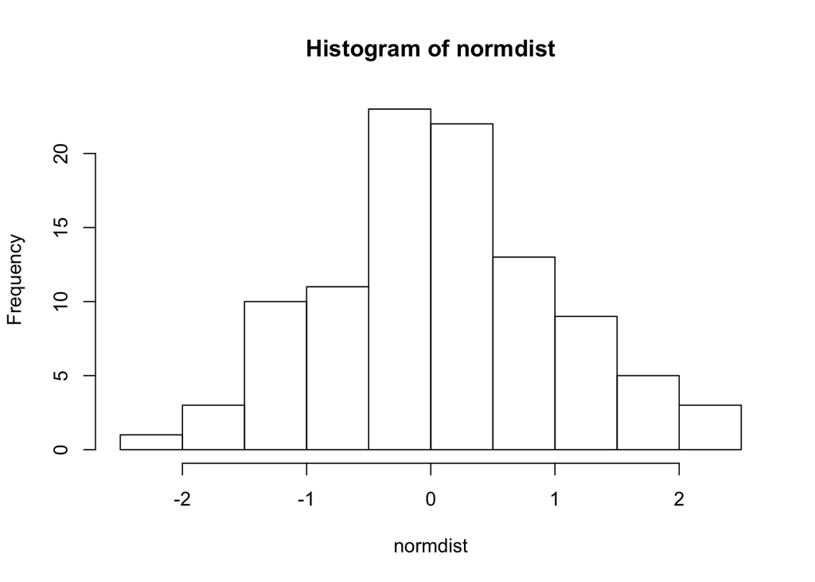

```r
# lets also look at the histogram
hist(normdist)
```

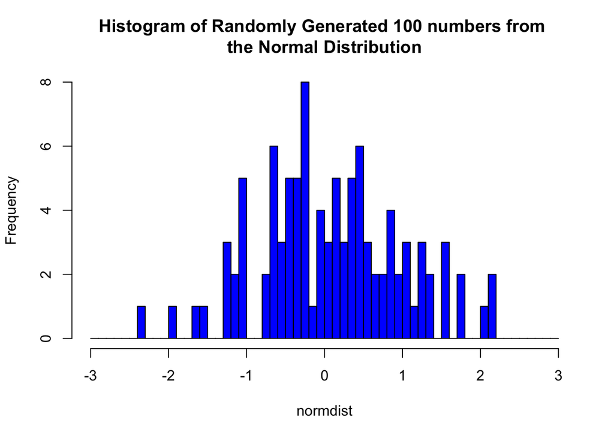

```r
# we can change the look of the histrogram somewhat by modifiying the breaks
# also lets add some color and a title!
hist(normdist, breaks = seq(-3, 3, 0.1), col = 'blue',
     main = paste0('Histogram of Randomly Generated 100 numbers from \n',
                   'the Normal Distribution'))
```

Is this what you expected? What about if we increase n to 1000?

```r
set.seed(123)
# generate 100 numbers with mean 0 and sd = 1
normdist <- rnorm(1000)
# lets get the mean and std of this vector
mean(normdist)
```

```
## [1] 0.01612787
```

```r
sd(normdist)
```

```
## [1] 0.991695
```

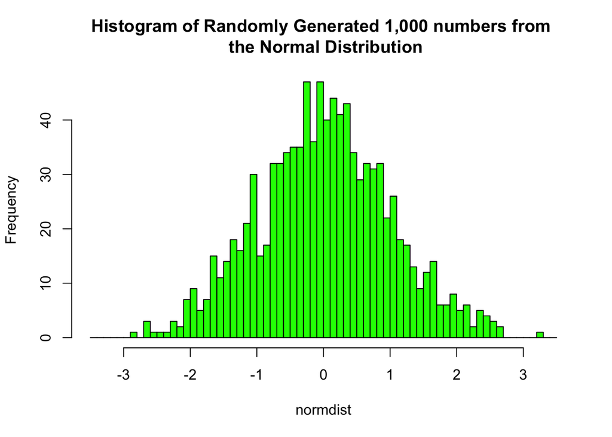

```r
# lets also look at the histogram
hist(normdist, breaks = seq(-3.5, 3.5, 0.1), col = 'green',
     main = paste0('Histogram of Randomly Generated 1,000 numbers from \n ',
                   'the Normal Distribution'))
```

```r
# for more information on the normal distribution and its associated functions
# in R
?Normal
```